# Project2_Regression_Mahdi

### Regression Task:

- Apply any two models with bagging and any two models with pasting.
- Apply any two models with AdaBoost boosting.
- Apply one model with gradient boosting.
- Apply PCA on data and then apply all the models in project 1 again on data you get from PCA. Compare your results with results in project 1. You don't need to apply all the models twice. Just copy the result table from project 1, prepare a similar table for all the models after PCA and compare both tables. Does PCA help in getting better results?
- Apply deep learning models covered in class

### Bagging

#### Decision tree with bagging

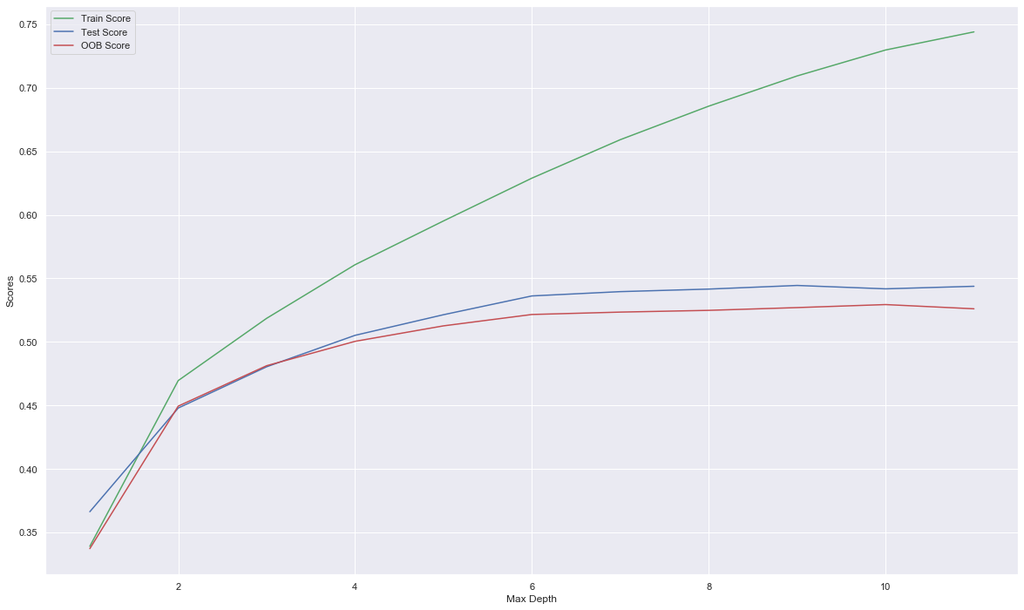

```python
from sklearn.ensemble import BaggingRegressor
from sklearn.tree import DecisionTreeRegressor
from sklearn.metrics import r2_score,mean_squared_error,mean_absolute_error
sns.set(rc={'figure.figsize':(20,12)})


train_score_array = []
test_score_array = []
oob_score_array=[]

for n in range(1,12):
    dt_reg = DecisionTreeRegressor(max_depth=n,random_state=0)
    bag_reg_dt = BaggingRegressor(dt_reg, n_estimators=50, max_samples=500, bootstrap=True,random_state=0,oob_score=True)
    bag_reg_dt.fit(X_train, y_train)
    train_score_array.append(bag_reg_dt.score(X_train, y_train))
    test_score_array.append(bag_reg_dt.score(X_test, y_test))
    oob_score_array.append(bag_reg_dt.oob_score_)

x_axis = range(1,12)
plt.plot(x_axis, train_score_array, c = 'g', label = 'Train Score')
plt.plot(x_axis, test_score_array, c = 'b', label = 'Test Score')
plt.plot(x_axis, oob_score_array, c = 'r', label = 'OOB Score')
plt.legend()
plt.xlabel('Max Depth')
plt.ylabel('Scores')
```

### Model 1

#### Random Forest

```python
from sklearn.ensemble import RandomForestRegressor
from sklearn.ensemble import BaggingRegressor
rf_reg = RandomForestRegressor(n_estimators=100,random_state=0)
bag_reg_rf = BaggingRegressor(rf_reg, n_estimators=100, max_samples=500, bootstrap=True,random_state=0,oob_score=True)
bag_reg_rf.fit(X_train, y_train)

y_pred=bag_reg_rf.predict(X_test)

print('Train score: {:.4f} %'.format(bag_reg_rf.score(X_train, y_train)*100))
print('Test score: {:.4f} %'.format(bag_reg_rf.score(X_test, y_test)*100))

bag_reg_rf_trainscore = bag_reg_rf.score(X_train, y_train)*100
bag_reg_rf_testscore = bag_reg_rf.score(X_test, y_test)*100

print('MAE: {:.4f}'.format(mean_absolute_error(y_test,y_pred)))
print('MSE: {:.4f}'.format(mean_squared_error(y_test,y_pred)))
print('RMSE: {:.4f}'.format(np.sqrt(mean_squared_error(y_test,y_pred))))
```

```
Train score: 70.6632 %
Test score: 55.2276 %
MAE: 0.3898
MSE: 0.2664
RMSE: 0.5161
```

SVM with RBF kernel

```python
from sklearn.svm import SVR, LinearSVR
from sklearn.ensemble import BaggingRegressor
svm_reg =  SVR(kernel='rbf',C=10,gamma=0.01)
bag_reg_rf = BaggingRegressor(svm_reg, n_estimators=100, max_samples=500, bootstrap=True,random_state=0,oob_score=True)
bag_reg_rf.fit(X_train, y_train)

y_pred=bag_reg_rf.predict(X_test)

print('Train score: {:.4f} %'.format(bag_reg_rf.score(X_train, y_train)*100))
print('Test score: {:.4f} %'.format(bag_reg_rf.score(X_test, y_test)*100))

print('MAE: {:.4f}'.format(mean_absolute_error(y_test,y_pred)))
print('MSE: {:.4f}'.format(mean_squared_error(y_test,y_pred)))
print('RMSE: {:.4f}'.format(np.sqrt(mean_squared_error(y_test,y_pred))))
```

```
Train score: 54.0936 %
Test score: 52.4472 %
MAE: 0.3932
MSE: 0.2829
RMSE: 0.5319
```

| Bagging Regressor Scores | Random Forest | SVM with RBF kernel |
| --- | --- | --- |
| Train | 70.6632 | 54.0936 |
| Test | 55.2276 | 52.4472 |

For the SVM (kernel=rbf) model and the Random forest regressor both test scores are shown above.